# Predicting Term Deposit Of Bank Marketing Dataset by Naive Bayes and Random Forest Models

Alvian Khairi

2022-06-07

# Intro

Abstract: The data is related with direct marketing campaigns (phone calls) of a Portuguese banking institution. The classification goal is to predict if the client will subscribe a term deposit (variable y).

Data Set Information: The data is related with direct marketing campaigns of a Portuguese banking institution. The marketing campaigns were based on phone calls. Often, more than one contact to the same client was required, in order to access if the product (bank term deposit) would be (‘yes’) or not (‘no’) subscribed.

Dataset from : http://archive.ics.uci.edu/ml/datasets/Bank+Marketing#

# Data Preparation

## Import Library

```r
library(dplyr)
library(caret)
library(e1071)
library(partykit)
library(ROCR)
library(rpart.plot)
library(randomForest)
```

## Read Data

```r
bank <- read.csv("data_input/bank-additional-full.csv", sep = ";", stringsAsFactors = T)
head(bank)
```

|  | age | job | marital | education | default | housing | loan | contact | month | day_of_week | duration | campaign | pdays | previous | poutcome | emp.var.rate | cons.price.idx | cons.conf.idx | euribor3m | nr.employed | y |
| --- | --- | --- | --- | --- | --- | --- | --- | --- | --- | --- | --- | --- | --- | --- | --- | --- | --- | --- | --- | --- | --- |
| 1 | 56 | housemaid | married | basic.4y | no | no | no | telephone | may | mon | 261 | 1 | 999 | 0 | nonexistent | 1.1 | 93.994 | -36.4 | 4.857 | 5191 | no |
| 2 | 57 | services | married | high.school | unknown | no | no | telephone | may | mon | 149 | 1 | 999 | 0 | nonexistent | 1.1 | 93.994 | -36.4 | 4.857 | 5191 | no |
| 3 | 37 | services | married | high.school | no | yes | no | telephone | may | mon | 226 | 1 | 999 | 0 | nonexistent | 1.1 | 93.994 | -36.4 | 4.857 | 5191 | no |
| 4 | 40 | admin. | married | basic.6y | no | no | no | telephone | may | mon | 151 | 1 | 999 | 0 | nonexistent | 1.1 | 93.994 | -36.4 | 4.857 | 5191 | no |
| 5 | 56 | services | married | high.school | no | no | yes | telephone | may | mon | 307 | 1 | 999 | 0 | nonexistent | 1.1 | 93.994 | -36.4 | 4.857 | 5191 | no |
| 6 | 45 | services | married | basic.9y | unknown | no | no | telephone | may | mon | 198 | 1 | 999 | 0 | nonexistent | 1.1 | 93.994 | -36.4 | 4.857 | 5191 | no |

```r
glimpse(bank)
```

```
#> Rows: 41,188
#> Columns: 21
#> $ age            <int> 56, 57, 37, 40, 56, 45, 59, 41, 24, 25, 41, 25, 29, 57,~
#> $ job            <fct> housemaid, services, services, admin., services, servic~
#> $ marital        <fct> married, married, married, married, married, married, m~
#> $ education      <fct> basic.4y, high.school, high.school, basic.6y, high.scho~
#> $ default        <fct> no, unknown, no, no, no, unknown, no, unknown, no, no, ~
#> $ housing        <fct> no, no, yes, no, no, no, no, no, yes, yes, no, yes, no,~
#> $ loan           <fct> no, no, no, no, yes, no, no, no, no, no, no, no, yes, n~
#> $ contact        <fct> telephone, telephone, telephone, telephone, telephone, ~
#> $ month          <fct> may, may, may, may, may, may, may, may, may, may, may, ~
#> $ day_of_week    <fct> mon, mon, mon, mon, mon, mon, mon, mon, mon, mon, mon, ~
#> $ duration       <int> 261, 149, 226, 151, 307, 198, 139, 217, 380, 50, 55, 22~
#> $ campaign       <int> 1, 1, 1, 1, 1, 1, 1, 1, 1, 1, 1, 1, 1, 1, 1, 1, 1, 1, 1~
#> $ pdays          <int> 999, 999, 999, 999, 999, 999, 999, 999, 999, 999, 999, ~
#> $ previous       <int> 0, 0, 0, 0, 0, 0, 0, 0, 0, 0, 0, 0, 0, 0, 0, 0, 0, 0, 0~
#> $ poutcome       <fct> nonexistent, nonexistent, nonexistent, nonexistent, non~
#> $ emp.var.rate   <dbl> 1.1, 1.1, 1.1, 1.1, 1.1, 1.1, 1.1, 1.1, 1.1, 1.1, 1.1, ~
#> $ cons.price.idx <dbl> 93.994, 93.994, 93.994, 93.994, 93.994, 93.994, 93.994,~
#> $ cons.conf.idx  <dbl> -36.4, -36.4, -36.4, -36.4, -36.4, -36.4, -36.4, -36.4,~
#> $ euribor3m      <dbl> 4.857, 4.857, 4.857, 4.857, 4.857, 4.857, 4.857, 4.857,~
#> $ nr.employed    <dbl> 5191, 5191, 5191, 5191, 5191, 5191, 5191, 5191, 5191, 5~
#> $ y              <fct> no, no, no, no, no, no, no, no, no, no, no, no, no, no,~
```

## Attribute Information:

### Bank client data:

- Age (numeric)
- Job : type of job (categorical: ‘admin.’, ‘blue-collar’, ‘entrepreneur’, ‘housemaid’, ‘management’, ‘retired’, ‘self-employed’, ‘services’, ‘student’, ‘technician’, ‘unemployed’, ‘unknown’)
- Marital : marital status (categorical: ‘divorced’, ‘married’, ‘single’, ‘unknown’ ; note: ‘divorced’ means divorced or widowed)
- Education (categorical: ‘basic.4y’, ‘basic.6y’, ‘basic.9y’, ‘high.school’, ‘illiterate’, ‘professional.course’, ‘university.degree’, ‘unknown’)
- Default: has credit in default? (categorical: ‘no’, ‘yes’, ‘unknown’)
- Housing: has housing loan? (categorical: ‘no’, ‘yes’, ‘unknown’)
- Loan: has personal loan? (categorical: ‘no’, ‘yes’, ‘unknown’)

### Related with the last contact of the current campaign:

- Contact: contact communication type (categorical: ‘cellular’,‘telephone’)
- Month: last contact month of year (categorical: ‘jan’, ‘feb’, ‘mar’, …, ‘nov’, ‘dec’)
- Day_of_week: last contact day of the week (categorical: ‘mon’,‘tue’,‘wed’,‘thu’,‘fri’)
- Duration: last contact duration, in seconds (numeric). Important note: this attribute highly affects the output target (e.g., if duration=0 then y=‘no’). Yet, the duration is not known before a call is performed. Also, after the end of the call y is obviously known. Thus, this input should only be included for benchmark purposes and should be discarded if the intention is to have a realistic predictive model.

### Other attributes:

- Campaign: number of contacts performed during this campaign and for this client (numeric, includes last contact)
- Pdays: number of days that passed by after the client was last contacted from a previous campaign (numeric; 999 means client was not previously contacted)
- Previous: number of contacts performed before this campaign and for this client (numeric)
- Poutcome: outcome of the previous marketing campaign (categorical: ‘failure’,‘nonexistent’,‘success’)

### Social and economic context attributes

- Emp.var.rate: employment variation rate - quarterly indicator (numeric)
- Cons.price.idx: consumer price index - monthly indicator (numeric)
- Cons.conf.idx: consumer confidence index - monthly indicator (numeric)
- Euribor3m: euribor 3 month rate - daily indicator (numeric)
- Nr.employed: number of employees - quarterly indicator (numeric)

### Output variable (desired target):

- y - has the client subscribed a term deposit? (binary: ‘yes’, ‘no’)

## Checking for missing values

```r
anyNA(bank)
```

```
#> [1] FALSE
```

> Data has no missing Value

# Pre-Processing Data

## Splitting Data

```r
RNGkind(sample.kind = "Rounding")
set.seed(200)

# index sampling
index <- sample(x = nrow(bank),
                size = nrow(bank)*0.8)

# splitting
bank_train <- bank[index, ]
bank_test <- bank[-index, ]
```

## Checking the balance of data proportion

```r
prop.table(table(bank_train$y))
```

```
#>
#>        no       yes
#> 0.8881335 0.1118665
```

> The proportion of the data is 8:1, unbalanced data proportion.

## Balancing Data

```r
RNGkind(sample.kind = "Rounding")

set.seed(123)

bank_train <- downSample(x = bank_train %>%
                           select(-y),
                         y = bank_train$y,
                         yname = "y")
```

```r
prop.table(table(bank_train$y))
```

```
#>
#>  no yes
#> 0.5 0.5
```

# Naïve Bayes Classifier Model

```r
model_naive <- naiveBayes(formula = y ~ ., data = bank_train, laplace = 1)
```

## ConfusionMatrix Evaluation

```r
test <- bank_test %>%  select(-y)
naive_pred <- predict(object = model_naive, newdata = test)

confusionMatrix(data = naive_pred, reference = bank_test$y, positive = "yes")
```

```
#> Confusion Matrix and Statistics
#>
#>           Reference
#> Prediction   no  yes
#>        no  5895  228
#>        yes 1389  726
#>
#>                Accuracy : 0.8037
#>                  95% CI : (0.795, 0.8122)
#>     No Information Rate : 0.8842
#>     P-Value [Acc > NIR] : 1
#>
#>                   Kappa : 0.373
#>
#>  Mcnemar's Test P-Value : <2e-16
#>
#>             Sensitivity : 0.76101
#>             Specificity : 0.80931
#>          Pos Pred Value : 0.34326
#>          Neg Pred Value : 0.96276
#>              Prevalence : 0.11580
#>          Detection Rate : 0.08813
#>    Detection Prevalence : 0.25674
#>       Balanced Accuracy : 0.78516
#>
#>        'Positive' Class : yes
#>
```

> The model has a fairly good accuracy and specificity in the 80% value range. but for sensitivity only around 76%.

## ROC Evaluation

```r
bank_test$pred <- predict(object = model_naive, newdata = bank_test, type = "raw")
bank_test$actual <- ifelse(test = bank_test$y == "yes", 1, 0)
```

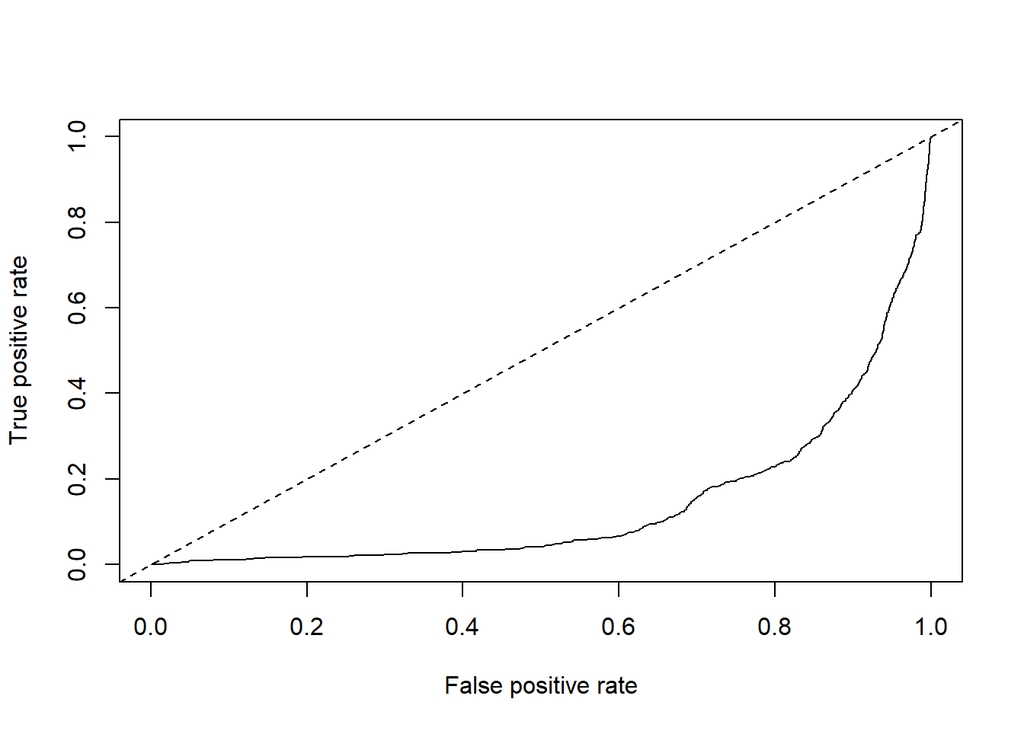

```r
# objek prediction
roc_pred <- prediction(predictions = bank_test$pred[,1], labels = bank_test$actual)

# ROC curve
plot(performance(prediction.obj = roc_pred, measure = "tpr", x.measure = "fpr"))
abline(0,1,lty = 8)
```

## AUC Evaluation

```r
vote_auc <- performance(prediction.obj = roc_pred, measure = "auc")
vote_auc@y.values
```

```
#> [[1]]
#> [1] 0.1379993
```

# Decision Tree Model

```r
model_tree <- ctree(formula = y ~ ., data = bank_train)
```

[figure not shown]

```r
plot(model_tree, type="simple")
```

```r
model_tree
```

```
#>
#> Model formula:
#> y ~ age + job + marital + education + default + housing + loan +
#>     contact + month + day_of_week + duration + campaign + pdays +
#>     previous + poutcome + emp.var.rate + cons.price.idx + cons.conf.idx +
#>     euribor3m + nr.employed
#>
#> Fitted party:
#> [1] root
#> |   [2] nr.employed <= 5076.2
#> |   |   [3] duration <= 123
#> |   |   |   [4] poutcome in failure, nonexistent
#> |   |   |   |   [5] duration <= 77: no (n = 42, err = 4.8%)
#> |   |   |   |   [6] duration > 77
#> |   |   |   |   |   [7] previous <= 1: no (n = 105, err = 45.7%)
#> |   |   |   |   |   [8] previous > 1: no (n = 12, err = 0.0%)
#> |   |   |   [9] poutcome in success: yes (n = 41, err = 19.5%)
#> |   |   [10] duration > 123
#> |   |   |   [11] poutcome in failure, nonexistent
#> |   |   |   |   [12] duration <= 261: yes (n = 472, err = 18.9%)
#> |   |   |   |   [13] duration > 261: yes (n = 731, err = 6.3%)
#> |   |   |   [14] poutcome in success: yes (n = 613, err = 4.1%)
#> |   [15] nr.employed > 5076.2
#> |   |   [16] duration <= 474
#> |   |   |   [17] month in apr, dec, mar, oct
#> |   |   |   |   [18] day_of_week in fri, mon
#> |   |   |   |   |   [19] month in apr, dec
#> |   |   |   |   |   |   [20] education in basic.4y, university.degree, unknown: yes (n = 70, err = 47.1%)
#> |   |   |   |   |   |   [21] education in basic.6y, basic.9y, high.school, professional.course: no (n = 80, err = 12.5%)
#> |   |   |   |   |   [22] month in mar, oct: yes (n = 50, err = 14.0%)
#> |   |   |   |   [23] day_of_week in thu, tue, wed
#> |   |   |   |   |   [24] default in no
#> |   |   |   |   |   |   [25] month in apr
#> |   |   |   |   |   |   |   [26] duration <= 96: no (n = 22, err = 18.2%)
#> |   |   |   |   |   |   |   [27] duration > 96: yes (n = 217, err = 22.6%)
#> |   |   |   |   |   |   [28] month in mar, oct: yes (n = 84, err = 3.6%)
#> |   |   |   |   |   [29] default in unknown: no (n = 14, err = 28.6%)
#> |   |   |   [30] month in aug, jul, jun, may, nov
#> |   |   |   |   [31] duration <= 364
#> |   |   |   |   |   [32] emp.var.rate <= -1.8
```

[output cut: 29 more lines]

```
#> |   |   |   |   [62] duration > 364
#> |   |   |   |   |   [63] cons.price.idx <= 92.893: yes (n = 86, err = 43.0%)
#> |   |   |   |   |   [64] cons.price.idx > 92.893
#> |   |   |   |   |   |   [65] contact in cellular: no (n = 137, err = 31.4%)
#> |   |   |   |   |   |   [66] contact in telephone: no (n = 124, err = 12.9%)
#> |   |   [67] duration > 474
#> |   |   |   [68] duration <= 635
#> |   |   |   |   [69] contact in cellular: yes (n = 346, err = 24.0%)
#> |   |   |   |   [70] contact in telephone
#> |   |   |   |   |   [71] cons.conf.idx <= -40.4: yes (n = 69, err = 30.4%)
#> |   |   |   |   |   [72] cons.conf.idx > -40.4: no (n = 77, err = 41.6%)
#> |   |   |   [73] duration > 635: yes (n = 1169, err = 11.4%)
#>
#> Number of inner nodes:    36
#> Number of terminal nodes: 37
```

```r
tree_pred <- predict(object = model_tree, newdata = bank_test)

confusionMatrix(data = tree_pred, reference = bank_test$y, positive = "yes")
```

```
#> Confusion Matrix and Statistics
#>
#>           Reference
#> Prediction   no  yes
#>        no  6073   69
#>        yes 1211  885
#>
#>                Accuracy : 0.8446
#>                  95% CI : (0.8366, 0.8524)
#>     No Information Rate : 0.8842
#>     P-Value [Acc > NIR] : 1
#>
#>                   Kappa : 0.5009
#>
#>  Mcnemar's Test P-Value : <2e-16
#>
#>             Sensitivity : 0.9277
#>             Specificity : 0.8337
#>          Pos Pred Value : 0.4222
#>          Neg Pred Value : 0.9888
#>              Prevalence : 0.1158
#>          Detection Rate : 0.1074
#>    Detection Prevalence : 0.2544
#>       Balanced Accuracy : 0.8807
#>
#>        'Positive' Class : yes
#>
```

## ROC Evaluation

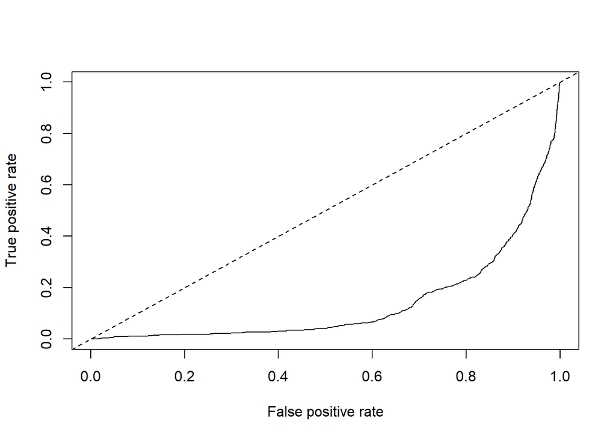

```r
# objek prediction
roc_pred <- prediction(predictions = bank_test$pred[,1], labels = bank_test$actual)

# ROC curve
plot(performance(prediction.obj = roc_pred, measure = "tpr", x.measure = "fpr"))
abline(0,1,lty = 8)
```

# Random Forest Model

## Data Preprocessing

```r
n0_var <- nearZeroVar(bank)
bank <- bank[ , -n0_var]
```

```r
head(bank)
```

|  | age | job | marital | education | default | housing | loan | contact | month | day_of_week | duration | campaign | previous | poutcome | emp.var.rate | cons.price.idx | cons.conf.idx | euribor3m | nr.employed | y |
| --- | --- | --- | --- | --- | --- | --- | --- | --- | --- | --- | --- | --- | --- | --- | --- | --- | --- | --- | --- | --- |
| 1 | 56 | housemaid | married | basic.4y | no | no | no | telephone | may | mon | 261 | 1 | 0 | nonexistent | 1.1 | 93.994 | -36.4 | 4.857 | 5191 | no |
| 2 | 57 | services | married | high.school | unknown | no | no | telephone | may | mon | 149 | 1 | 0 | nonexistent | 1.1 | 93.994 | -36.4 | 4.857 | 5191 | no |
| 3 | 37 | services | married | high.school | no | yes | no | telephone | may | mon | 226 | 1 | 0 | nonexistent | 1.1 | 93.994 | -36.4 | 4.857 | 5191 | no |
| 4 | 40 | admin. | married | basic.6y | no | no | no | telephone | may | mon | 151 | 1 | 0 | nonexistent | 1.1 | 93.994 | -36.4 | 4.857 | 5191 | no |
| 5 | 56 | services | married | high.school | no | no | yes | telephone | may | mon | 307 | 1 | 0 | nonexistent | 1.1 | 93.994 | -36.4 | 4.857 | 5191 | no |
| 6 | 45 | services | married | basic.9y | unknown | no | no | telephone | may | mon | 198 | 1 | 0 | nonexistent | 1.1 | 93.994 | -36.4 | 4.857 | 5191 | no |

## Cross Validation

```r
RNGkind(sample.kind = "Rounding")
set.seed(200)

# index sampling
index <- sample(x = nrow(bank),
                size = nrow(bank)*0.8)

# splitting
bank_train2 <- bank[index, ]
bank_test2 <- bank[-index, ]
```

## Model Fitting

```r
set.seed(417)

ctrl <- trainControl(method = "repeatedcv",
                     number = 5, # k-fold
                    repeats = 3) # repetisi

bank_forest<- train(y ~ .,
                    data = bank_train2,
                    method = "rf", # random forest
                    trControl = ctrl)

saveRDS(bank_forest, "bank_forest.RDS") # save model
```

```r
b_forest <- readRDS("bank_forest.RDS")
```

```r
b_forest$finalModel
```

```
#>
#> Call:
#>  randomForest(x = x, y = y, mtry = min(param$mtry, ncol(x)))
#>                Type of random forest: classification
#>                      Number of trees: 500
#> No. of variables tried at each split: 27
#>
#>         OOB estimate of  error rate: 8.58%
#> Confusion matrix:
#>        no  yes class.error
#> no  28117 1147  0.03919492
#> yes  1680 2006  0.45577862
```

## Confusion Matrix

```r
pred_forest <- predict(object = b_forest, newdata = bank_test2, type = "raw")
```

```r
confusionMatrix(data = pred_forest, reference = bank_test2$y, positive = "yes")
```

```
#> Confusion Matrix and Statistics
#>
#>           Reference
#> Prediction   no  yes
#>        no  6978  415
#>        yes  306  539
#>
#>                Accuracy : 0.9125
#>                  95% CI : (0.9062, 0.9185)
#>     No Information Rate : 0.8842
#>     P-Value [Acc > NIR] : < 2.2e-16
#>
#>                   Kappa : 0.5503
#>
#>  Mcnemar's Test P-Value : 5.767e-05
#>
#>             Sensitivity : 0.56499
#>             Specificity : 0.95799
#>          Pos Pred Value : 0.63787
#>          Neg Pred Value : 0.94387
#>              Prevalence : 0.11580
#>          Detection Rate : 0.06543
#>    Detection Prevalence : 0.10257
#>       Balanced Accuracy : 0.76149
#>
#>        'Positive' Class : yes
#>
```

> The model has a fairly high accuracy of 91.25%, but the sensitivity/recall value is very small at 56.49%

# Conclusion

based on the highest accuracy value, the random forest model has the highest accuracy, but in this case the recall value will be used as a comparison between the models. this is done to meet business needs, that the false negative value is very important to reconsider. then based on the recall value, the decision tree model is the best model for this case with a recall of 92.77%.